# Activity Report

Rusell Glynn

10/22/2021

### 1. Read in dataset and process data

```r
library(dplyr)
```

```r
library(ggplot2)
library(readr)
library(lubridate)
library(naniar)
# read in data

rawexdata <- read.csv('activity.csv')

# remove NAs and convert date to factor

exdata <- rawexdata %>% filter(steps != 'NA')
exdata$date <- as.factor(ymd(exdata$date))
#exdata$interval <- factor(exdata$interval)
```

### 2. Create histogram of the total number to steps taken per day

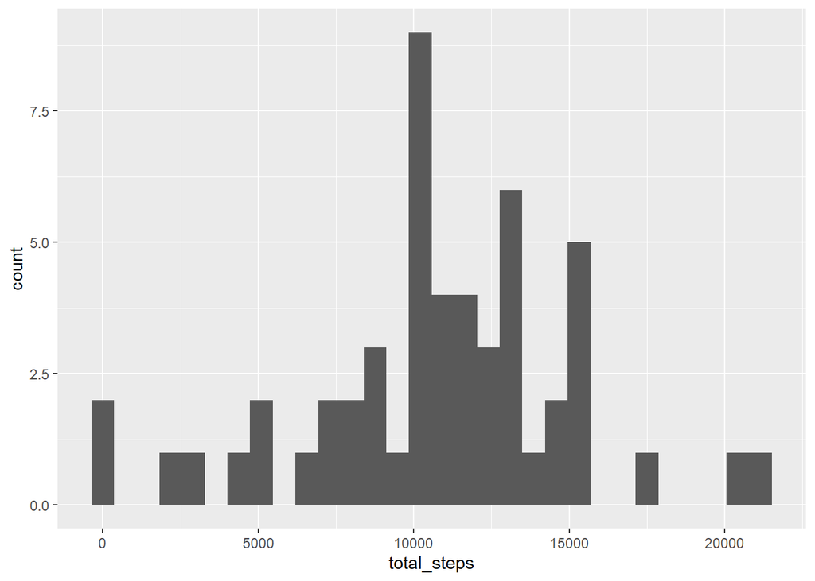

```r
stepsperday <- exdata %>% group_by(date) %>% summarize(total_steps = sum(steps))
ggplot(stepsperday, aes(total_steps)) +
    geom_histogram()
```

### 3. Mean and median number of steps per day

```r
stepsperday %>% summarize(mean = mean(total_steps),
                          median =  median(total_steps))
```

```
## # A tibble: 1 x 2
##     mean median
##    <dbl>  <int>
## 1 10766.  10765
```

### 4. Time series plot of the average number of steps taken

```r
meaninterval <- exdata %>% group_by(interval) %>% summarize(mean = mean(steps))
str(meaninterval)
```

```
## tibble [288 x 2] (S3: tbl_df/tbl/data.frame)
##  $ interval: int [1:288] 0 5 10 15 20 25 30 35 40 45 ...
##  $ mean    : num [1:288] 1.717 0.3396 0.1321 0.1509 0.0755 ...
```

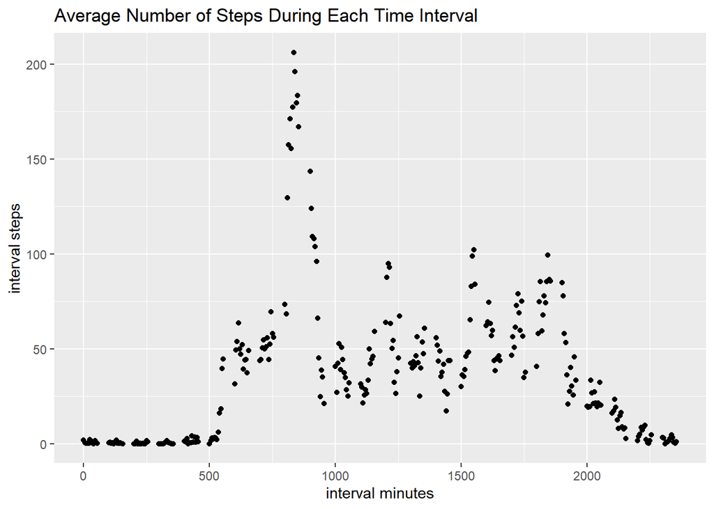

```r
ggplot(meaninterval, aes(interval, mean)) +
    geom_point() +
    ggtitle('Average Number of Steps During Each Time Interval') +
    xlab('interval minutes') +
    ylab('interval steps')
```

### 5. The 5-minute interval that, on average, contains the maximum nummber of steps

```r
maxinterval <- meaninterval %>% filter(mean == max(mean))
maxinterval$interval
```

```
## [1] 835
```

### Code to describe missing data

```r
missingdata <- apply(is.na(rawexdata), 2, sum)
missingdata
```

```
##    steps     date interval
##     2304        0        0
```

All of the missing data are located in the steps variable.

Looking at the missing data to determine which intervals have missing data, we create a missing variable summary report (missdata).

```r
missdata <- rawexdata %>% group_by(interval) %>% select(interval, steps) %>% miss_var_summary()
head(missdata)
```

```
## # A tibble: 6 x 4
## # Groups:   interval [6]
##   interval variable n_miss pct_miss
##      <int> <chr>     <int>    <dbl>
## 1        0 steps         8     13.1
## 2        5 steps         8     13.1
## 3       10 steps         8     13.1
## 4       15 steps         8     13.1
## 5       20 steps         8     13.1
## 6       25 steps         8     13.1
```

```r
unique(missdata$n_miss)
```

```
## [1] 8
```

It looks like every interval has exactly 8 missing values in the steps variable.

We can look at the number of consecutive rows are missing steps data.

```r
rawexdata$date <- as.factor(ymd(rawexdata$date))
missdatarun <- rawexdata %>% group_by(interval) %>%
    select(interval, steps) %>% miss_var_run(steps)
sumrun <- missdatarun %>% summary
sumrun
```

```
##     interval        run_length        is_na
##  Min.   :   0.0   Min.   : 1.000   Length:3744
##  1st Qu.: 588.8   1st Qu.: 1.000   Class :character
##  Median :1177.5   Median : 2.000   Mode  :character
##  Mean   :1177.5   Mean   : 4.692
##  3rd Qu.:1766.2   3rd Qu.: 4.000
##  Max.   :2355.0   Max.   :23.000
```

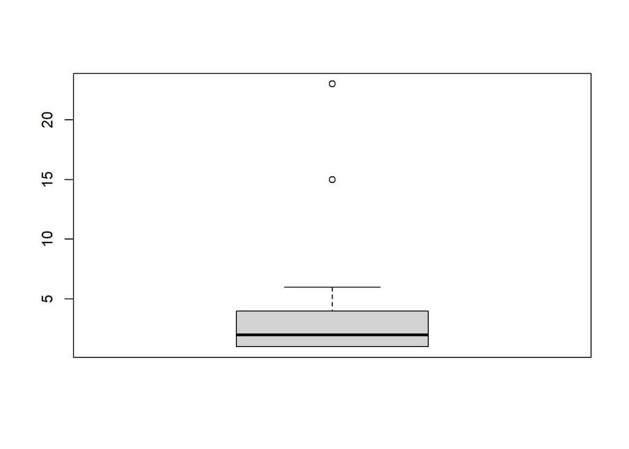

```r
boxplot(missdatarun$run_length)
```

We can see that the median missing run length is 2. However, we have two outliers at 23 and 15 with a median of 2.

### Devise a strategy for filling in all of the missing values in the dataset.

We will impute the missing values in the dataset by using the median or each interval. We will store the data in a new dataset called imputerawexdata.

```r
# imputing by median of interval

navector <- which(is.na(rawexdata))

medianinterval <- rawexdata %>% group_by(interval) %>% summarise(median = median(steps, na.rm = T))
imputerawexdata <- rawexdata
getmedian <- function(x) {
    y <-which(medianinterval$interval == x)
    intsteps <- medianinterval[y,2]
}

for(i in seq_along(navector)) {
    y = navector[i]
    z <- rawexdata[y,3]
    q <- getmedian(as.numeric(z))
    imputerawexdata[y,1] <- q
}
```

### Create a histogram of imputed data total steps per day. Report the mean and median total steps per day using this new dataset.

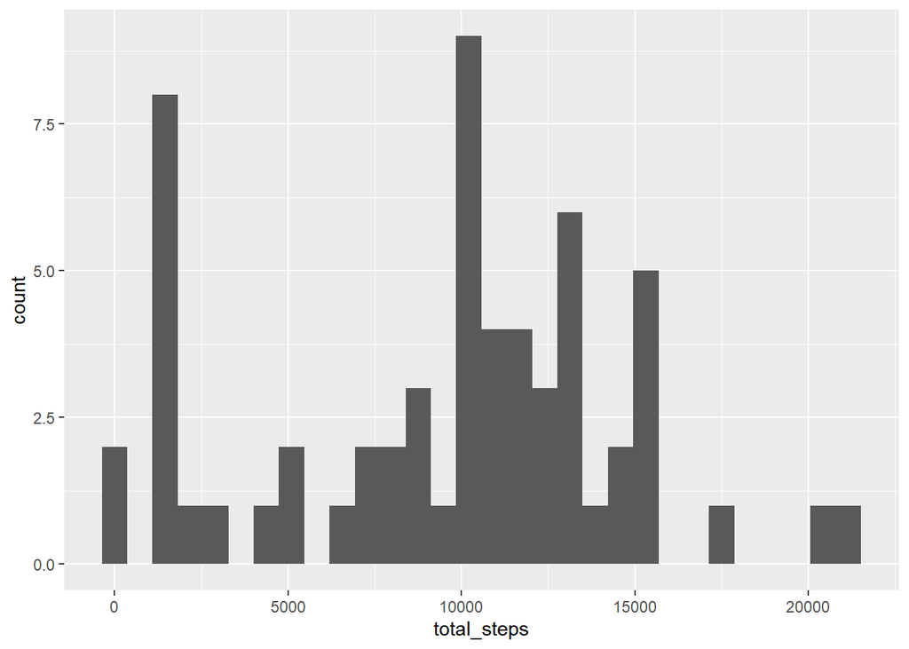

```r
stepsperday <- imputerawexdata %>% group_by(date) %>% summarize(total_steps = sum(steps))
ggplot(stepsperday, aes(total_steps)) +
    geom_histogram()
```

Mean and median of the new dataset:

```r
stepsperday %>% summarize(mean = mean(total_steps),
                          median =  median(total_steps))
```

```
## # A tibble: 1 x 2
##    mean median
##   <dbl>  <int>
## 1 9504.  10395
```

The mean is considerably lower than the previously calculated mean with NAs excluded. The median is only slightly lower.

```r
imputerawexdata$date <- as.Date(imputerawexdata$date)
imputerawexdata <- imputerawexdata %>% mutate(weekday = weekdays(date))
days <- imputerawexdata %>% group_by(weekday) %>% summarize(total_steps = sum(steps))
imputerawexdata <- imputerawexdata %>%
    mutate(day_type = ifelse(weekday %in% c('Saturday', 'Sunday'),'weekend','weekday'))
imputerawexdata$day_type <- as.factor(imputerawexdata$day_type)
str(imputerawexdata)
```

```
## 'data.frame':    17568 obs. of  5 variables:
##  $ steps   : int  0 0 0 0 0 0 0 0 0 0 ...
##  $ date    : Date, format: "2012-10-01" "2012-10-01" ...
##  $ interval: int  0 5 10 15 20 25 30 35 40 45 ...
##  $ weekday : chr  "Monday" "Monday" "Monday" "Monday" ...
##  $ day_type: Factor w/ 2 levels "weekday","weekend": 1 1 1 1 1 1 1 1 1 1 ...
```

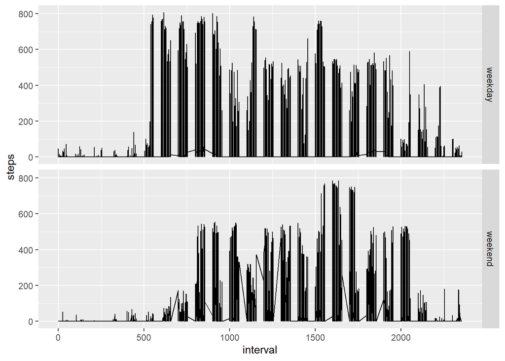

[output not shown]

```r
imputerawexdata %>% ggplot(aes(interval, steps)) +
    geom_line() +
     facet_grid(day_type ~ .)
```